# MIS-64060 Final Exam

Antonio Garlisi

2022-11-28

```r
universal.df <- read.csv("C:\\Users\\Andrew Garlisi\\Downloads\\mlb-umpire-scorecard.csv" , header=TRUE, stringsAsFactors=FALSE)
#Downloaded from https://www.kaggle.com/datasets/mattop/mlb-baseball-umpire-scorecards-2015-2022
install.packages("dplyr", repos ="http://cran.us.r-project.org")
library(dplyr)
install.packages("factoextra", repos ="http://cran.us.r-project.org")
library(factoextra)
install.packages("flexclust",repos = "http://cran.us.r-project.org")
library(flexclust)
install.packages("ggsignif", repos = "http://cran.us.r-project.org")
library(ggsignif)
install.packages("backports",repos = "http://cran.us.r-project.org")
library(backports)
install.packages("rstatix",repos = "http://cran.us.r-project.org")
library(rstatix)
summary(universal.df)
```

```
##        id            date              umpire              home
##  Min.   :    1   Length:18213       Length:18213       Length:18213
##  1st Qu.: 4554   Class :character   Class :character   Class :character
##  Median : 9107   Mode  :character   Mode  :character   Mode  :character
##  Mean   : 9107
##  3rd Qu.:13660
##  Max.   :18213
##      away           home_team_runs   away_team_runs   pitches_called
##  Length:18213       Min.   : 0.000   Min.   : 0.000   Length:18213
##  Class :character   1st Qu.: 2.000   1st Qu.: 2.000   Class :character
##  Mode  :character   Median : 4.000   Median : 4.000   Mode  :character
##                     Mean   : 4.559   Mean   : 4.433
##                     3rd Qu.: 6.000   3rd Qu.: 6.000
##                     Max.   :29.000   Max.   :28.000
##  incorrect_calls    expected_incorrect_calls correct_calls
##  Length:18213       Length:18213             Length:18213
##  Class :character   Class :character         Class :character
##  Mode  :character   Mode  :character         Mode  :character
##
##
##
##  expected_correct_calls correct_calls_above_expected   accuracy
##  Length:18213           Length:18213                 Length:18213
##  Class :character       Class :character             Class :character
##  Mode  :character       Mode  :character             Mode  :character
##
##
##
##  expected_accuracy  accuracy_above_expected consistency
##  Length:18213       Length:18213            Length:18213
##  Class :character   Class :character        Class :character
##  Mode  :character   Mode  :character        Mode  :character
##
##
##
##   favor_home        total_run_impact
##  Length:18213       Length:18213
##  Class :character   Class :character
##  Mode  :character   Mode  :character
##
##
##
```

```r
Data <-  subset(universal.df, select = -c(1,2,4,5,6,7)) #Remove columns that are not relevant and Convert All Data into Numeric Data
Data$pitches_called <- as.numeric(Data$pitches_called)
Data$incorrect_calls <- as.numeric(Data$incorrect_calls)
Data$expected_incorrect_calls <- as.numeric(Data$expected_incorrect_calls)
Data$correct_calls <- as.numeric(Data$correct_calls)
Data$expected_correct_calls <- as.numeric(Data$expected_correct_calls)
Data$correct_calls_above_expected <- as.numeric(Data$correct_calls_above_expected)
Data$accuracy <- as.numeric(Data$accuracy)
Data$expected_accuracy <- as.numeric(Data$expected_accuracy)
Data$accuracy_above_expected <- as.numeric(Data$accuracy_above_expected)
Data$consistency <- as.numeric(Data$consistency)
Data$favor_home <- as.numeric(Data$favor_home)
Data$total_run_impact <- as.numeric(Data$total_run_impact)
summary(Data)
```

```
##     umpire          pitches_called  incorrect_calls expected_incorrect_calls
##  Length:18213       Min.   : 68.0   Min.   : 0.0    Min.   : 3.10
##  Class :character   1st Qu.:138.0   1st Qu.: 8.0    1st Qu.: 9.60
##  Mode  :character   Median :153.0   Median :11.0    Median :11.60
##                     Mean   :154.6   Mean   :11.7    Mean   :11.92
##                     3rd Qu.:169.0   3rd Qu.:14.0    3rd Qu.:13.90
##                     Max.   :375.0   Max.   :45.0    Max.   :43.90
##                     NA's   :120     NA's   :120     NA's   :120
##  correct_calls   expected_correct_calls correct_calls_above_expected
##  Min.   : 63.0   Min.   : 63.0          Min.   :-24.5000
##  1st Qu.:127.0   1st Qu.:127.5          1st Qu.: -1.9000
##  Median :141.0   Median :141.1          Median :  0.4000
##  Mean   :142.9   Mean   :142.6          Mean   :  0.2114
##  3rd Qu.:156.0   3rd Qu.:155.9          3rd Qu.:  2.5000
##  Max.   :331.0   Max.   :331.1          Max.   : 16.1000
##  NA's   :120     NA's   :120            NA's   :120
##     accuracy      expected_accuracy accuracy_above_expected  consistency
##  Min.   : 78.40   Min.   :85.00     Min.   :-11.7000        Min.   : 81.40
##  1st Qu.: 90.70   1st Qu.:91.20     1st Qu.: -1.3000        1st Qu.: 91.70
##  Median : 92.70   Median :92.50     Median :  0.2000        Median : 93.30
##  Mean   : 92.42   Mean   :92.28     Mean   :  0.1356        Mean   : 93.17
##  3rd Qu.: 94.40   3rd Qu.:93.50     3rd Qu.:  1.7000        3rd Qu.: 94.70
##  Max.   :100.00   Max.   :97.40     Max.   :  9.4000        Max.   :100.00
##  NA's   :120      NA's   :120       NA's   :120             NA's   :120
##    favor_home       total_run_impact
##  Min.   :-3.45000   Min.   :0.000
##  1st Qu.:-0.33000   1st Qu.:0.970
##  Median : 0.03000   Median :1.410
##  Mean   : 0.03454   Mean   :1.532
##  3rd Qu.: 0.40000   3rd Qu.:1.950
##  Max.   : 3.40000   Max.   :7.140
##  NA's   :120        NA's   :120
```

```r
nonaData <- na.omit(Data)
newdf <- nonaData %>% group_by(umpire) %>% summarise_each(funs(mean))
head(newdf)
```

```
## # A tibble: 6 × 13
##   umpire         pitches_called incorrect_calls expected_incorrec… correct_calls
##   <chr>                   <dbl>           <dbl>              <dbl>         <dbl>
## 1 Adam Beck                153.            8.56              10.4           144.
## 2 Adam Hamari              152.           10.5               11.7           141.
## 3 Adrian Johnson           156.           13.0               12.2           143.
## 4 Alan Porter              156.           10.4               12.0           145.
## 5 Alex MacKay              153.            8.83               9.02          144
## 6 Alex Tosi                157.            8.63              11.3           148.
## # … with 8 more variables: expected_correct_calls <dbl>,
## #   correct_calls_above_expected <dbl>, accuracy <dbl>,
## #   expected_accuracy <dbl>, accuracy_above_expected <dbl>, consistency <dbl>,
## #   favor_home <dbl>, total_run_impact <dbl>
```

```r
metricsdf <- subset (newdf, select =-c(2,3,4,5,6,8,9))
#Since the main focus is on umpire performance above or below the acceptable/expected level, the relevant stats are the the correct calls and accuracy compared to those expectations along with overall accuracy, potential bias for home or away team, and impact on runs. All other numbers are factored into those key metrics and we don't need to see the individual entries.
head(metricsdf)
```

```
## # A tibble: 6 × 6
##   umpire         correct_calls_above_ex… accuracy_above_… consistency favor_home
##   <chr>                            <dbl>            <dbl>       <dbl>      <dbl>
## 1 Adam Beck                        1.8              1.20         94.1    0.00177
## 2 Adam Hamari                      1.20             0.777        93.5   -0.0226
## 3 Adrian Johnson                  -0.854           -0.535        92.8    0.0710
## 4 Alan Porter                      1.60             1.04         93.5   -0.0302
## 5 Alex MacKay                      0.183            0            93.7    0.25
## 6 Alex Tosi                        2.63             1.67         93.6    0.150
## # … with 1 more variable: total_run_impact <dbl>
```

```r
rownames(metricsdf) <- metricsdf$umpire
metricsdf$umpire <- NULL
normdf <- scale(metricsdf)
head(normdf)
```

```
##      correct_calls_above_expected accuracy_above_expected consistency
## [1,]                   1.28517120               1.3121123   1.6930681
## [2,]                   0.80117398               0.7932280   0.5287273
## [3,]                  -0.87271998              -0.8301581  -0.6791146
## [4,]                   1.12480251               1.1225877   0.6094562
## [5,]                  -0.02923043              -0.1684605   0.9439074
## [6,]                   1.95639523               1.9001465   0.8234086
##      favor_home total_run_impact
## [1,] -0.2910064       -1.4287472
## [2,] -0.4856616       -0.9388331
## [3,]  0.2607901        0.5402487
## [4,] -0.5460718       -0.6999696
## [5,]  1.6873307       -1.5986647
## [6,]  0.8866329       -1.6499882
```

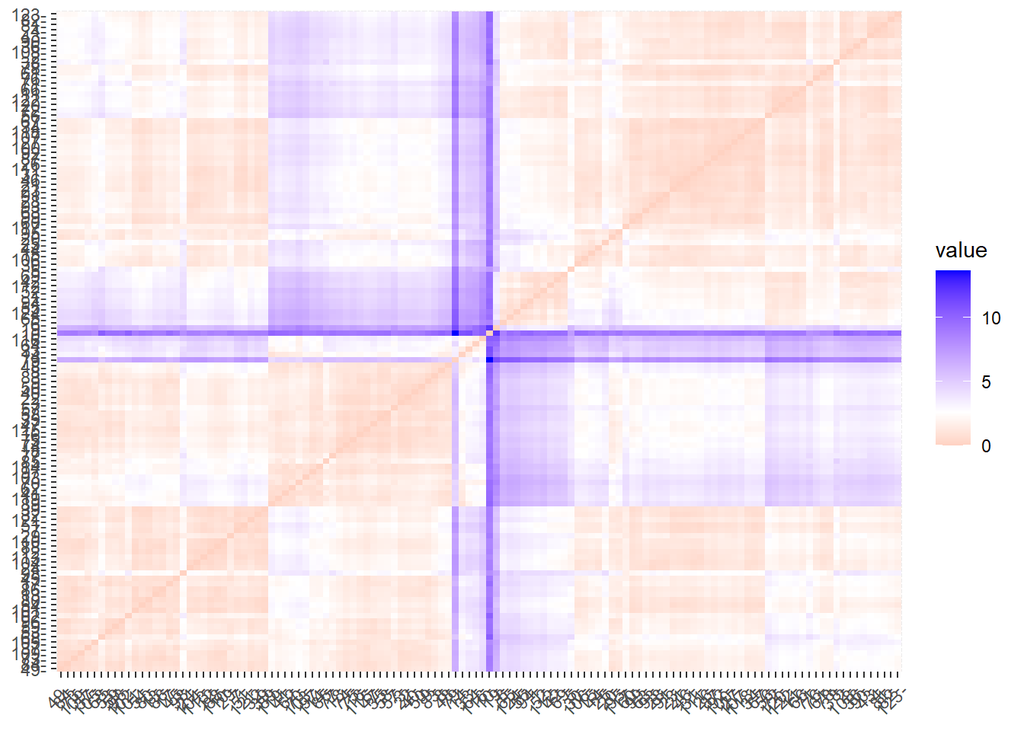

```r
distance <- get_dist(normdf)
fviz_dist(distance)
```

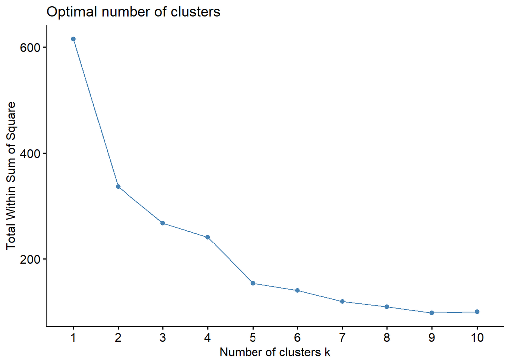

```r
fviz_nbclust(normdf, kmeans, method="wss")
```

#There appears to be elbows between 2-5 as reasonble numbers of clusters

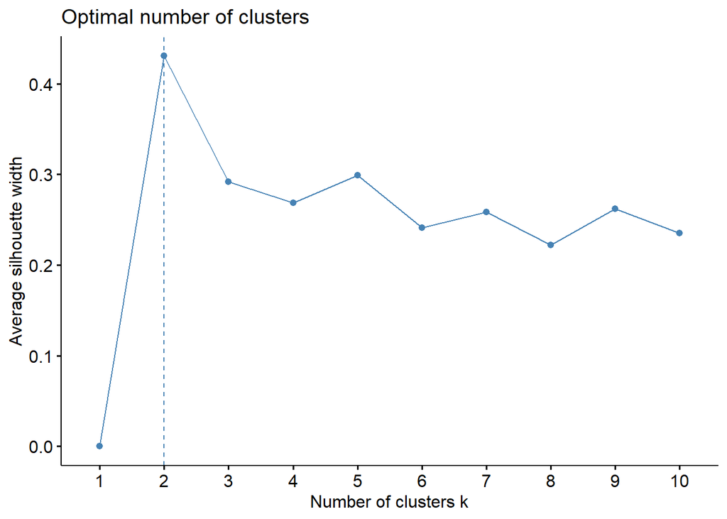

```r
fviz_nbclust(normdf, kmeans, method="silhouette")
```

#The silhouette method confirms 2 is the optimal number of clusters. This can be used to define the umpires that are performing well and the umpires that are underperforming. If we wanted to include a few groups in the middle (ie:average performers who may not need extensive training but some guidance), we could include additional clusters.

```r
k2 <- kmeans(normdf, centers = 2, nstart = 25)
```

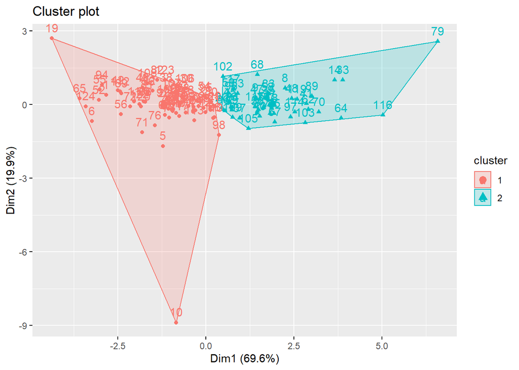

```r
fviz_cluster(k2, data = normdf)
```

```r
k2$centers
```

```
##   correct_calls_above_expected accuracy_above_expected consistency favor_home
## 1                    0.6309703               0.6262481   0.5328498  0.1013532
## 2                   -0.9990363              -0.9915595  -0.8436788 -0.1604759
##   total_run_impact
## 1       -0.5783485
## 2        0.9157184
```

#Cluster 1 is comprised of the umpires with higher performance metrics while cluster 2 is comprised of the umpires with performance issues.

#In order to have a better idea of how to handle assignments for important post season games and offseason training for the umpires, it seems better to break the data down into additional clusters.

```r
k5 <- kmeans(normdf, centers = 5, nstart = 25)
```

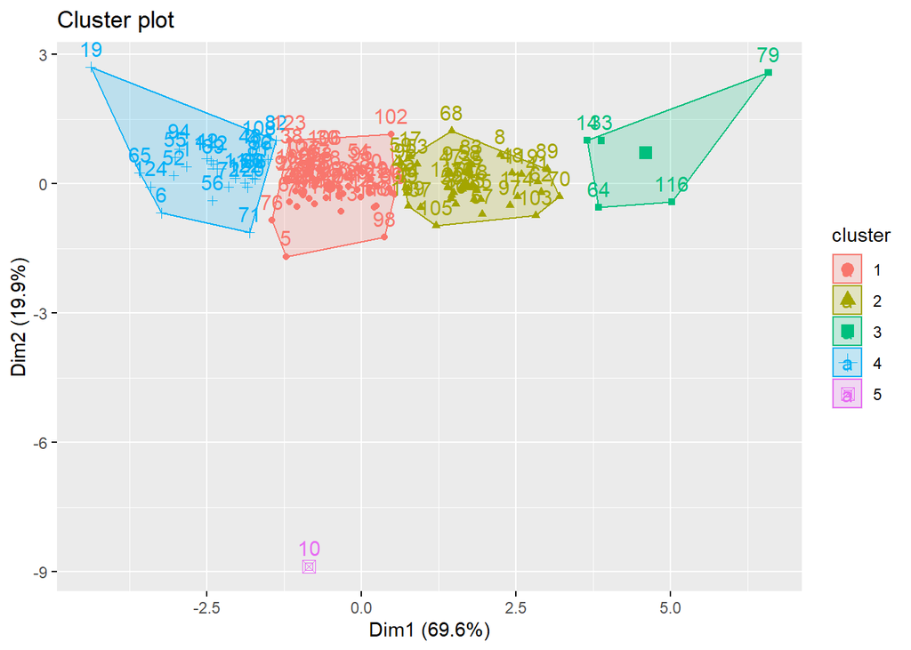

```r
fviz_cluster(k5, data = normdf)
```

```r
k5$centers
```

```
##   correct_calls_above_expected accuracy_above_expected consistency  favor_home
## 1                   0.25541260              0.25167027   0.2095231  0.08145916
## 2                  -0.94583013             -0.93195415  -0.6525896 -0.06442308
## 3                  -1.93768962             -1.97355696  -2.7750502 -0.89991634
## 4                   1.27445917              1.26616228   1.0420217 -0.23713471
## 5                  -0.09698309             -0.04474683   1.1289590  8.86024885
##   total_run_impact
## 1       -0.2900646
## 2        0.8105035
## 3        2.4898540
## 4       -1.1074636
## 5        0.1085695
```

#Out of the five clusters, there are four sizable groups and one cluster with an outlier (Cluster 5 comprised of only Anthony Johnson) that was not assigned to another cluster likely due to his Favor Home metric being significantly higher than the others. Based on the summarized data, Cluster 4 is the group of the highest performers, Cluster 1 is performing as expected, cluster 2 is performing below average, and cluster 3 is the group of lowest performance. Based on this information, it would make sense to assign Clusters 4 and 1 to playoff games, primetime national games, and the World Series. Cluster 2 should receive some guidance to improve performance but they may not be making enough errors to warrant drastic measures. Cluster 3 has the worst performance and would benefit from extensive offseason training and possible shadowing of Cluster 4. Cluster 5 is close to being in the middle of most performance metrics outside of favor_home so Anthony Johnson may be able to do a good job with some additional training with an emphasis on resisting being influenced by home crowds.